# The Impact of Cognitive Disability on Employment Status Pre & Post COVID-19

## Authors: Camila Castaneda, Elena Sabin, Jonatan Peguero, and Sammi Tucker

[figure not shown]

# Table of Contents

# Introduction

Employment can play a fundamental role in shaping one's identity and self-worth. For those with cognitive disabilities, finding stable employment can significantly increase self-confidence, social inclusion, and personal autonomy, providing a pathway to a more independent life. The labor market outcomes for individuals with disabilities highlight persistent disparities in participation, employment, and unemployment rates compared to those without disabilities. While there have been gradual improvements in certain metrics, significant barriers remain, particularly for individuals with intellectual and cognitive disabilities. This project aims to investigate the dynamics of employment for those with disabilities, particularly individuals with cognitive challenges. This is critical for addressing broad issues relating to economic inclusion, social equity, and personal well-being. The data analysis included below is filtered for the years 2018 and 2022 since the COVID-19 pandemic further exacerbated these disparities, introducing new challenges while intensifying pre-existing inequalities.

The employment of individuals with disabilities contributes to a more diverse and productive workforce. Understanding and working to ensure their participation not only will strengthen economic output but could reduce individuals' dependence on social welfare programs which can reduce economic strain. Calls for inclusivity and fairness, like those articulated in the United Nations Sustainable Development Goals (SDGs), which emphasize the importance of work for all, regardless of ability. It is vital to examine the data surrounding employment to find out what work still needs to be done to meet these goals. We hope to test which factors are most significant in creating these gaps. Are differences influenced mostly by demographic characteristics like age gender or location? Or primarily by socioeconomic factors like income and education? We use regression analyses on different variables to investigate how these different elements interact to impact employment outcomes.

In recent years there has been increasing awareness of disability rights and inclusivity, but persistent structural barriers still hinder equitable access to employment opportunities. Despite legislative frameworks that aim at protecting individuals with disabilities, gaps remain in workplace participation rates, wages, and job stability. To design effective policies and interventions to negate these disparities we must try to assess the magnitude of these issues.

# Literature Review

The COVID-19 pandemic created additional obstacles for workers with disabilities. The pandemic-induced economic downturn disproportionately affected vulnerable populations, including those with disabilities, who were more likely to face layoffs or reductions in hours. Industries employing a high proportion of disabled workers, such as hospitality and retail, experienced significant disruptions, further limiting job opportunities. Furthermore, the transition to remote work often excluded individuals with disabilities due to inadequate access to technology and insufficient workplace accommodations.

Labor force participation and employment rates for individuals with disabilities consistently lag behind those without disabilities. For instance, in 2018, the employment-population ratio for individuals with disabilities was 19.1%, compared to 65.9% for those without disabilities. By 2022, this figure had increased to 21.3%, marking the highest level since data collection began in 2008. However, the employment–population ratio for individuals without disabilities remained substantially higher at 65.4% (Bureau of Labor Statistics [BLS], 2023).The figure below, provided by the Bureau of Labor Statistics, highlights the drastic difference in the labor market of those with and without disabilties. It also shows the unemployment rate for both demographic groups, furhter emphasizing those with diabilites inability to join the labor force.

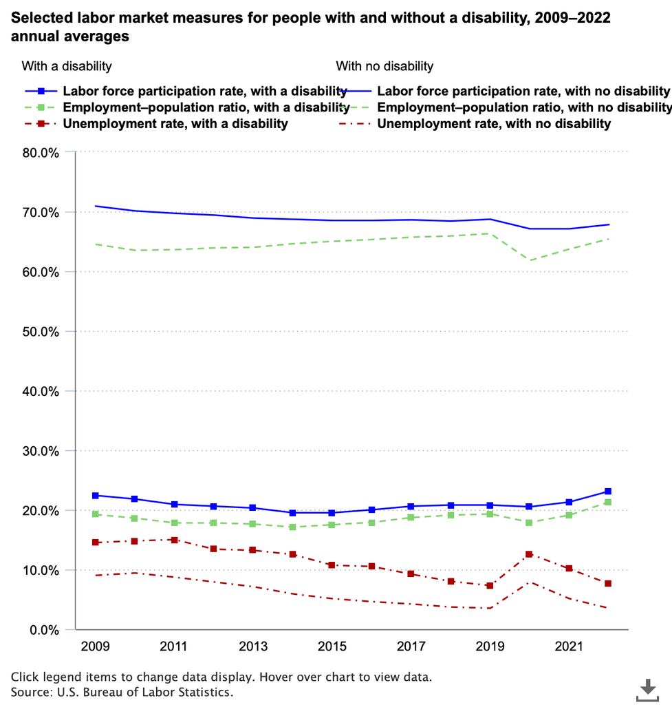

For adults aged 21–64 with intellectual disabilities, the disparities are even starker. Only 44% are part of the labor force, compared to 83% of those without disabilities, and their unemployment rate is more than double, at 21% versus 8%. Alarmingly, 28% of working-age adults with intellectual disabilities have never held a job. Underemployment is also widespread, with many working fewer hours or earning lower wages than their non-disabled counterparts (Siperstein et al., 2018).

These challenges were amplified by the pandemic. Individuals with intellectual disabilities often require job accommodations or supportive environments, both of which were disrupted by pandemic-related closures and operational changes. However, for those already employed in accommodated environments, job stability remained a strength; 81% of these individuals had been in their current roles for over three years, showcasing their reliability as employees when given the proper resources (Siperstein et al., 2018).

Structural barriers and employer perceptions have long hindered the employment prospects of individuals with disabilities. Before the pandemic, only 34.9% of disabled individuals were employed, compared to 76% of those without disabilities. Employers' "pessimistic views" about the abilities of disabled individuals have frequently resulted in discriminatory hiring practices (JSTOR, 2019).

The pandemic intensified these biases as employers faced unprecedented uncertainty and often opted to retain or hire individuals perceived as less "risky" hires. Studies show that people with cognitive disabilities, such as math or reading disabilities, consistently struggle more than those without disabilities to find and maintain employment, a trend that worsened amid the pandemic’s economic challenges (Sage Journals, 2018).

However, while the pandemic accelerated these trends, the disparity in participation between those with and without disabilities has long existed. The U.S. labor force participation rate declined significantly over recent decades, dropping by 3.3% between 2001 and 2013 among working-age adults (21–65), with only 75% of this group working or actively seeking work. A significant contributor to this decline was individuals with disabilities, who accounted for 32% of those outside the workforce. From 2001 to 2014, the participation rate for people with disabilities fell from 25% to 16%, with the Great Recession exacerbating this trend. Figure 1 below illustrates the rising number of disabled individuals not participating in the labor force, while Figure 2 shows the overall drop in labor force participation (American Institutes for Research, 2015)

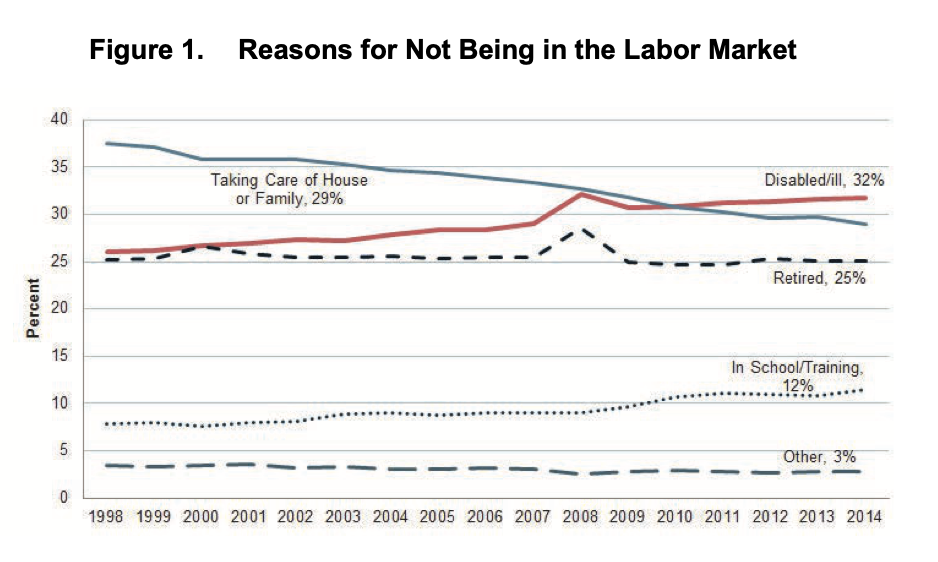

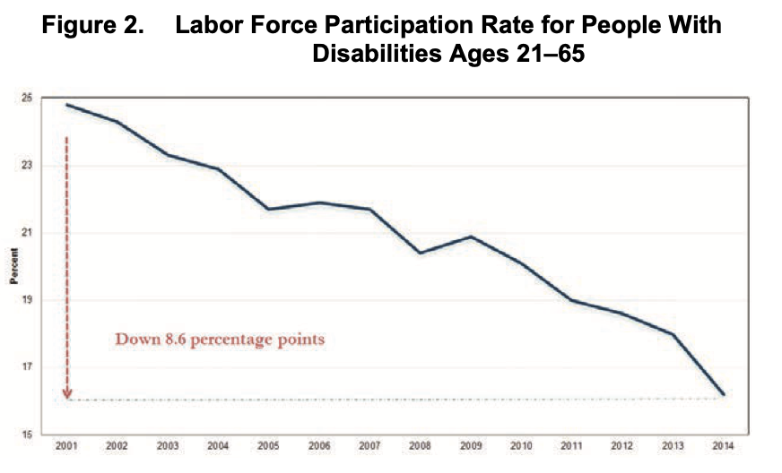

Furthermore, the demonstrated job stability among individuals in accommodated environments underscores the importance of inclusive workplace practices. By addressing employer biases, improving remote work infrastructure, and fostering supportive environments we can build a more equitable labor market. For policymakers, the insights can inform more specific interventions to reduce employment inequalities, ensuring resources are allocated to address barriers. For employers, understanding these dynamics can guide the creation of more inclusive hiring practices and workplace environments which would benefit both employees and organizations. This is particularly critical as the economy continues to recover from the pandemic’s impact, offering a unique opportunity to reimagine workforce inclusion strategies for individuals with disabilities.

# Data

## B.Variable Inspection

[output not shown]

## C.Data Import and Cleaning

```python
# import libraries
import pandas as pd
import numpy as np
import matplotlib.pyplot as plt
import matplotlib.image as mpimg
import seaborn as sns
import statsmodels.api as sm
import statsmodels.formula.api as smf
pd.options.display.float_format = '{:.3f}'.format
from stargazer.stargazer import Stargazer
import scipy.stats as stats
from IPython.core.display import HTML
import statsmodels.stats.diagnostic as smd
from statsmodels.stats.outliers_influence import variance_inflation_factor
!pip install matplotlib-venn
```

```python
import pyreadstat
ipums = pd.read_csv('/Users/camilacastaneda/Downloads/usa_00004.csv')
ipums = ipums[['EMPSTAT', 'DIFFREM', 'AGE', 'SEX', 'RACE', 'EDUC', 'MARST', 'HHINCOME', 'YEAR', 'DIFFEYE', 'DIFFHEAR']]
```

```python
ipums.info()
```

```
<class 'pandas.core.frame.DataFrame'>
RangeIndex: 15721123 entries, 0 to 15721122
Data columns (total 11 columns):
 #   Column    Dtype
---  ------    -----
 0   EMPSTAT   int64
 1   DIFFREM   int64
 2   AGE       int64
 3   SEX       int64
 4   RACE      int64
 5   EDUC      int64
 6   MARST     int64
 7   HHINCOME  int64
 8   YEAR      int64
 9   DIFFEYE   int64
 10  DIFFHEAR  int64
dtypes: int64(11)
memory usage: 1.3 GB
```

```python
#Filter year 2018 and 2022
ipums = ipums[ipums['YEAR'].isin([2018, 2022])]
#Clean EMPSTAT
ipums['Unemployed'] = ipums['EMPSTAT'].apply(lambda x: 1 if x ==1 else (0 if x==2 else np.nan))
ipums = ipums.dropna(subset=['Unemployed'])
#Clean DIFFREM
ipums['CognitiveDis'] = ipums['DIFFREM']==2
ipums['CognitiveDis'] = ipums['CognitiveDis'].astype(int)
#Clean AGE
ipums['Young'] = ipums['AGE']<=29
ipums['Young'] = ipums['Young'].astype(int)

def fage(x):
    if 30<=x<=50:
        return 1
    else:
        return 0

ipums['Middle'] = ipums['AGE'].apply(fage)
ipums['Middle'].value_counts(dropna=False)

ipums['Senior'] = ipums['AGE']>=50
ipums['Senior'] = ipums['Senior'].astype(int)

group = ['Young', 'Middle', 'Senior']
limit = [16, 30, 51, 65]
ipums['age_cat'] = pd.cut(ipums['AGE'], bins=limit, labels=group, right=False)
# 'right=False' so that we have 0->17, 18->64, 65->120
#ipums.drop(columns=['AGE_Young', 'AGE_Middle', 'AGE_Senior'], inplace=True)
ipums['age_cat'].value_counts(sort=False)
#Clean SEX
ipums['Female'] = ipums['SEX']==2
ipums['Female'] = ipums['Female'].astype(int)

#Clean MARST
ipums['Married'] = ipums['MARST'].apply(lambda x: 1 if x==1 else 0)

#Clean EDUC
education_mapping = {
    0: 0,
    1: 2.5,
    2: 6.5,
    3: 9,
    4: 10,
    5: 11,
    6: 12,
    7: 13,
    8: 14,
    9: 15,
    10: 16,
    11: 17}
ipums['EDUC'] = ipums['EDUC'].map(education_mapping)
```

```python
#Clean HHINCOME
ipums['HHINCOME'] = pd.to_numeric(ipums['HHINCOME'], errors='coerce')
ipums_cleaned = ipums[(ipums['HHINCOME'] != 9999999) & (ipums['HHINCOME'] >= 0)]
ipums_cleaned = ipums_cleaned.reset_index(drop=True)
print(ipums['HHINCOME'].unique())
```

```
[9999999   96400   59100 ...  128890   56604  599420]
```

```python
#Clean RACE
ipums['White'] = ipums['RACE']==1
ipums['White'] = ipums['White'].astype(int)
ipums['Black'] = ipums['RACE']==2
ipums['Black'] = ipums['Black'].astype(int)
ipums['OtherRace'] = ipums['RACE']>=3
ipums['OtherRace'] = ipums['OtherRace'].astype(int)
ipums['RACE'] = ipums['RACE'].map({1: 0, 2:1}).fillna(2).astype(int)
ipums['Race_cat'] = ipums['RACE'].map({0: 'White', 1: 'Black', 2: 'OtherRace'})
print(ipums['RACE'].value_counts())
```

```
0    2323830
2     618358
1     279148
Name: RACE, dtype: int64
```

## D. Data Visualization

### Percentage of Responders in Each Age Group

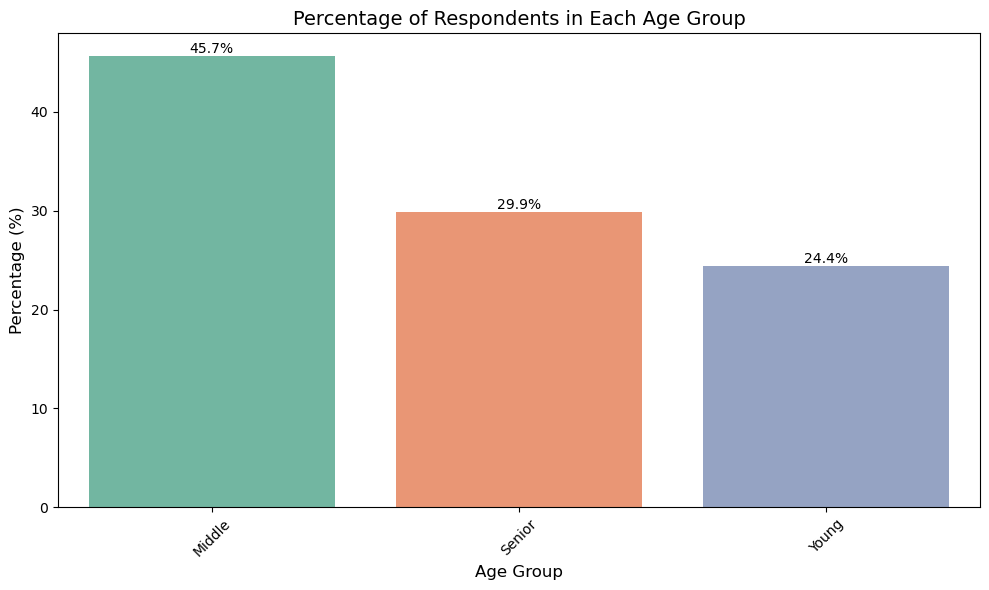

```python
age_group_percent = ipums['age_cat'].value_counts(normalize=True) * 100


#  cross-tab to count employment status within each age group
employment_by_age = pd.crosstab(ipums['age_cat'], ipums['EMPSTAT'], normalize='index') * 100

# Assuming `age_group_percent` is already created and properly sorted
plt.figure(figsize=(10, 6))

# Create the bar plot
barplot = sns.barplot(
    x=age_group_percent.index,
    y=age_group_percent.values,
    order=age_group_percent.index,  # Explicitly specify the order
    palette='Set2'
)

# Add percentage annotations to the correct bars
for bar, label in zip(barplot.patches, age_group_percent):
    barplot.annotate(
        f"{label:.1f}%",  # Format label as percentage
        (bar.get_x() + bar.get_width() / 2, bar.get_height()),  # Centered above the bar
        ha='center', va='bottom', fontsize=10, color='black'
    )

# Customize the plot
plt.title('Percentage of Respondents in Each Age Group', fontsize=14)
plt.xlabel('Age Group', fontsize=12)
plt.ylabel('Percentage (%)', fontsize=12)
plt.xticks(rotation=45, fontsize=10)
plt.tight_layout()

# Show the plot
plt.show()
```

This graph provides a clearer understanding of the demographic composition of our sample. This is important because it helps contextualize the results of our regression models, revealing whether certain age groups are over- or underrepresented. If age distribution is skewed, it could influence the interpretation of relationships between age and other variables, such as employment status or cognitive disabilities. Understanding the age breakdown ensures that our findings are more reliable and that potential age-related effects are accurately captured in our analysis.

### Employment Status Trends by Age Group

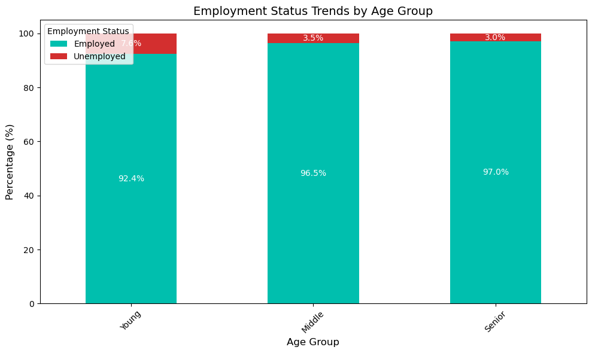

```python
import matplotlib.pyplot as plt

# Assuming `employment_by_age` DataFrame is already created with percentages
plt.figure(figsize=(10, 6))

# Plot the stacked bar chart
ax = employment_by_age.plot(
    kind='bar',
    stacked=True,
    color=['#00bfae', '#d32f2f'],
    figsize=(10, 6)
)

# Annotate each bar segment
for idx, bars in enumerate(ax.containers):  # Iterate over bar segments
    for bar in bars:  # Iterate over each bar in a segment
        if bar.get_height() > 0:  # Only annotate non-zero bars
            # Get the position and value
            x = bar.get_x() + bar.get_width() / 2  # Center of the bar
            y = bar.get_y() + bar.get_height() / 2  # Middle of the segment
            percentage = f"{bar.get_height():.1f}%"  # Format percentage

            # Add text annotation
            ax.text(x, y, percentage, ha='center', va='center', fontsize=10, color='white')

# Customize the plot
plt.title('Employment Status Trends by Age Group', fontsize=14)
plt.xlabel('Age Group', fontsize=12)
plt.ylabel('Percentage (%)', fontsize=12)
plt.xticks(rotation=45, fontsize=10)
plt.yticks(fontsize=10)
plt.legend(['Employed', 'Unemployed'], title='Employment Status', loc='upper left')
plt.tight_layout()
plt.show()
```

Knowing the trends in employment status by age group adds meaningful context to our analysis by revealing how employment patterns vary across different times in life. It allows us to examine whether certain age groups face unique employment challenges or exhibit distinct employment behaviors. For example, younger individuals might experience higher unemployment rates or lower participation in the workforce compared to older age groups, who may have more stable employment. Understanding these trends helps in interpreting the relationship between age and employment status, offering a more nuanced view of the workforce.

[figure not shown]

```python
import pandas as pd
import matplotlib.pyplot as plt
import seaborn as sns

# Assuming the data is correctly preprocessed as in your example
employment_2018 = (
    ipums[ipums['YEAR'] == 2018]
        .groupby('age_cat')['Unemployed']
        .apply(lambda x: 100 * (1 - x.mean()))  # Calculate employment rate
        .reset_index(name='Employment Rate (%)')
)
employment_2018['Year'] = 2018

employment_2022 = (
    ipums[ipums['YEAR'] == 2022]
        .groupby('age_cat')['Unemployed']
        .apply(lambda x: 100 * (1 - x.mean()))  # Calculate employment rate
        .reset_index(name='Employment Rate (%)')
)
employment_2022['Year'] = 2022

employment_combined = pd.concat([employment_2018, employment_2022])

# Create the bar plot
plt.figure(figsize=(10, 6))
barplot = sns.barplot(
    x='age_cat',
    y='Employment Rate (%)',
    hue='Year',
    data=employment_combined,
    palette='viridis'
)

# Add percentage annotations
for bar in barplot.patches:
    # Get the height of each bar
    height = bar.get_height()
    # Get the x position and width to center the text
    x_pos = bar.get_x() + bar.get_width() / 2
    # Annotate the bar
    barplot.text(x=x_pos, y=height + 0, s=f"{height:.1f}%",
                 ha='center', va='bottom', fontsize=10, color='black')

# Customize the plot
plt.title('Employment Rate by Age Group for 2018 and 2022', fontsize=14)
plt.xlabel('Age Group', fontsize=12)
plt.ylabel('Employment Rate (%)', fontsize=12)
plt.xticks(rotation=45)
plt.legend(title='Year', fontsize=10)
plt.tight_layout()

# Show the plot
plt.show()
```

This graph allows us to directly compare changes in employment rates across different age groups over time. This comparison helps to highlight any shifts in employment patterns that may have occurred between 2018 and 2022, which is important for understanding the impact of external factors such as policies, the labor market, or significant events like the COVID-19 pandemic. By focusing on age groups, we can assess whether certain groups experienced disproportionate changes in employment. This analysis helps to identify trends in workforce participation and uncover potential disparities faced by specific age groups in the labor market.

[figure not shown]

```python
import matplotlib.pyplot as plt
import seaborn as sns
import pandas as pd

# Assuming `cognitive_dis_data` and `unemployment_by_age` are already created
# Step 1: Filter for individuals with cognitive disabilities
cognitive_dis_data = ipums[ipums['CognitiveDis'] == 1]

# Step 2: Calculate unemployment percentage by age group
unemployment_by_age = (
    cognitive_dis_data.groupby('age_cat')['Unemployed']
    .mean() * 100
).reset_index()

# Step 3: Plot the data
plt.figure(figsize=(10, 6))
barplot = sns.barplot(x='age_cat', y='Unemployed', data=unemployment_by_age, palette='coolwarm')

# Annotate bars with percentage values
for index, row in unemployment_by_age.iterrows():
    barplot.text(index, row['Unemployed'] + 1, f"{row['Unemployed']:.1f}%",
                 color='black', ha='center', fontsize=10)

# Customize the plot
plt.title('Percentage of People with Cognitive Disabilities Who Are Unemployed by Age Group', fontsize=14)
plt.xlabel('Age Group', fontsize=12)
plt.ylabel('Unemployment Percentage (%)', fontsize=12)
plt.xticks(rotation=45, fontsize=10)
plt.yticks(fontsize=10)
plt.ylim(0, 100)

# Show the plot
plt.tight_layout()
plt.show()
```

# Economic Modeling

Back to Table of Contents

## Regression Models

$$employment status = \beta_0 + \beta_1*cognitivedifficulty + \beta_2*age + \beta_3*sex + \beta_4*race + \beta_5*education + \beta_6*maritalstatus + u $$

```python
modelprelim = smf.ols(
    formula="Unemployed ~ CognitiveDis + Young + Senior + Female + White + Black + EDUC + Married",
    data=ipums
).fit()
modelprelim.summary()
```

OLS Regression Results

| Dep. Variable: | Unemployed | R-squared: | 0.024 |
| --- | --- | --- | --- |
| Model: | OLS | Adj. R-squared: | 0.024 |
| Method: | Least Squares | F-statistic: | 9894. |
| Date: | Fri, 06 Dec 2024 | Prob (F-statistic): | 0.00 |
| Time: | 08:55:10 | Log-Likelihood: | 6.2600e+05 |
| No. Observations: | 3221336 | AIC: | -1.252e+06 |
| Df Residuals: | 3221327 | BIC: | -1.252e+06 |
| Df Model: | 8 |  |  |
| Covariance Type: | nonrobust |  |  |

|  | coef | std err | t | P>\|t\| | [0.025 | 0.975] |
| --- | --- | --- | --- | --- | --- | --- |
| Intercept | 0.8912 | 0.001 | 1399.375 | 0.000 | 0.890 | 0.892 |
| CognitiveDis | -0.0885 | 0.001 | -122.518 | 0.000 | -0.090 | -0.087 |
| Young | -0.0240 | 0.000 | -76.767 | 0.000 | -0.025 | -0.023 |
| Senior | 0.0044 | 0.000 | 17.250 | 0.000 | 0.004 | 0.005 |
| Female | 0.0021 | 0.000 | 9.404 | 0.000 | 0.002 | 0.003 |
| White | 0.0072 | 0.000 | 25.081 | 0.000 | 0.007 | 0.008 |
| Black | -0.0261 | 0.000 | -57.253 | 0.000 | -0.027 | -0.025 |
| EDUC | 0.0040 | 4.16e-05 | 95.641 | 0.000 | 0.004 | 0.004 |
| Married | 0.0262 | 0.000 | 106.160 | 0.000 | 0.026 | 0.027 |

| Omnibus: | 2773022.395 | Durbin-Watson: | 1.931 |
| --- | --- | --- | --- |
| Prob(Omnibus): | 0.000 | Jarque-Bera (JB): | 52720848.807 |
| Skew: | -4.379 | Prob(JB): | 0.00 |
| Kurtosis: | 20.779 | Cond. No. | 92.5 |

Notes:  
[1] Standard Errors assume that the covariance matrix of the errors is correctly specified.

```python
# Incremental models based on modelprelim
spec_1 = smf.ols(formula="Unemployed ~ CognitiveDis", data=ipums).fit()
spec_2 = smf.ols(formula="Unemployed ~ CognitiveDis + Young", data=ipums).fit()
spec_3 = smf.ols(formula="Unemployed ~ CognitiveDis + Young + Senior", data=ipums).fit()
spec_4 = smf.ols(formula="Unemployed ~ CognitiveDis + Young + Senior + Female", data=ipums).fit()
spec_5 = smf.ols(formula="Unemployed ~ CognitiveDis + Young + Senior + Female + White", data=ipums).fit()
spec_6 = smf.ols(formula="Unemployed ~ CognitiveDis + Young + Senior + Female + White + Black", data=ipums).fit()
spec_7 = smf.ols(formula="Unemployed ~ CognitiveDis + Young + Senior + Female + White + Black + EDUC", data=ipums).fit()
spec_8 = smf.ols(formula="Unemployed ~ CognitiveDis + Young + Senior + Female + White + Black + EDUC + Married", data=ipums).fit()

# Create table using Stargazer
table = Stargazer([spec_1, spec_2, spec_3, spec_4, spec_5, spec_6, spec_7, spec_8])
table.title("Incremental Models of Unemployment")
table.custom_columns(
    ["Spec 1", "Spec 2", "Spec 3", "Spec 4", "Spec 5", "Spec 6", "Spec 7", "Spec 8"],
    [1, 1, 1, 1, 1, 1, 1, 1]
)
table.covariate_order(['Intercept', 'CognitiveDis', 'Young', 'Senior', 'Female', 'White', 'Black', 'EDUC', 'Married'])

# Render the table
table
```

Incremental Models of Unemployment

|  | *Dependent variable: Unemployed* |  |  |  |  |  |  |  |
| --- | --- | --- | --- | --- | --- | --- | --- | --- |
|  | Spec 1 | Spec 2 | Spec 3 | Spec 4 | Spec 5 | Spec 6 | Spec 7 | Spec 8 |
|  | (1) | (2) | (3) | (4) | (5) | (6) | (7) | (8) |
| Intercept | 0.960*** | 0.969*** | 0.967*** | 0.966*** | 0.952*** | 0.960*** | 0.901*** | 0.891*** |
|  | (0.000) | (0.000) | (0.000) | (0.000) | (0.000) | (0.000) | (0.001) | (0.001) |
| CognitiveDis | -0.103*** | -0.098*** | -0.098*** | -0.098*** | -0.098*** | -0.097*** | -0.093*** | -0.089*** |
|  | (0.001) | (0.001) | (0.001) | (0.001) | (0.001) | (0.001) | (0.001) | (0.001) |
| Young |  | -0.042*** | -0.039*** | -0.039*** | -0.039*** | -0.039*** | -0.035*** | -0.024*** |
|  |  | (0.000) | (0.000) | (0.000) | (0.000) | (0.000) | (0.000) | (0.000) |
| Senior |  |  | 0.005*** | 0.005*** | 0.003*** | 0.004*** | 0.006*** | 0.004*** |
|  |  |  | (0.000) | (0.000) | (0.000) | (0.000) | (0.000) | (0.000) |
| Female |  |  |  | 0.002*** | 0.002*** | 0.003*** | 0.001*** | 0.002*** |
|  |  |  |  | (0.000) | (0.000) | (0.000) | (0.000) | (0.000) |
| White |  |  |  |  | 0.021*** | 0.011*** | 0.008*** | 0.007*** |
|  |  |  |  |  | (0.000) | (0.000) | (0.000) | (0.000) |
| Black |  |  |  |  |  | -0.030*** | -0.031*** | -0.026*** |
|  |  |  |  |  |  | (0.000) | (0.000) | (0.000) |
| EDUC |  |  |  |  |  |  | 0.004*** | 0.004*** |
|  |  |  |  |  |  |  | (0.000) | (0.000) |
| Married |  |  |  |  |  |  |  | 0.026*** |
|  |  |  |  |  |  |  |  | (0.000) |
| Observations | 3221336 | 3221336 | 3221336 | 3221336 | 3221336 | 3221336 | 3221336 | 3221336 |
| R<sup>2</sup> | 0.006 | 0.014 | 0.014 | 0.014 | 0.016 | 0.017 | 0.021 | 0.024 |
| Adjusted R<sup>2</sup> | 0.006 | 0.014 | 0.014 | 0.014 | 0.016 | 0.017 | 0.021 | 0.024 |
| Residual Std. Error | 0.201 (df=3221334) | 0.200 (df=3221333) | 0.200 (df=3221332) | 0.200 (df=3221331) | 0.200 (df=3221330) | 0.200 (df=3221329) | 0.200 (df=3221328) | 0.199 (df=3221327) |
| F Statistic | 20029.975*** (df=1; 3221334) | 22206.419*** (df=2; 3221333) | 14932.012*** (df=3; 3221332) | 11213.117*** (df=4; 3221331) | 10341.815*** (df=5; 3221330) | 9345.569*** (df=6; 3221329) | 9663.920*** (df=7; 3221328) | 9894.247*** (df=8; 3221327) |
| Note: | *p<0.1; **p<0.05; ***p<0.01 |  |  |  |  |  |  |  |

```python
# Filter data for 2018 and 2022
ipums_2018 = ipums[ipums['YEAR'] == 2018]
ipums_2022 = ipums[ipums['YEAR'] == 2022]

# Models for 2018
spec_1_2018 = smf.ols(formula="Unemployed ~ CognitiveDis", data=ipums_2018).fit()
spec_2_2018 = smf.ols(formula="Unemployed ~ CognitiveDis + Young", data=ipums_2018).fit()
spec_3_2018 = smf.ols(formula="Unemployed ~ CognitiveDis + Young + Senior", data=ipums_2018).fit()
spec_4_2018 = smf.ols(formula="Unemployed ~ CognitiveDis + Young + Senior + Female", data=ipums_2018).fit()
spec_5_2018 = smf.ols(formula="Unemployed ~ CognitiveDis + Young + Senior + Female + White", data=ipums_2018).fit()
spec_6_2018 = smf.ols(formula="Unemployed ~ CognitiveDis + Young + Senior + Female + White + Black", data=ipums_2018).fit()
spec_7_2018 = smf.ols(formula="Unemployed ~ CognitiveDis + Young + Senior + Female + White + Black + EDUC", data=ipums_2018).fit()
spec_8_2018 = smf.ols(formula="Unemployed ~ CognitiveDis + Young + Senior + Female + White + Black + EDUC + Married", data=ipums_2018).fit()

# Models for 2022
spec_1_2022 = smf.ols(formula="Unemployed ~ CognitiveDis", data=ipums_2022).fit()
spec_2_2022 = smf.ols(formula="Unemployed ~ CognitiveDis + Young", data=ipums_2022).fit()
spec_3_2022 = smf.ols(formula="Unemployed ~ CognitiveDis + Young + Senior", data=ipums_2022).fit()
spec_4_2022 = smf.ols(formula="Unemployed ~ CognitiveDis + Young + Senior + Female", data=ipums_2022).fit()
spec_5_2022 = smf.ols(formula="Unemployed ~ CognitiveDis + Young + Senior + Female + White", data=ipums_2022).fit()
spec_6_2022 = smf.ols(formula="Unemployed ~ CognitiveDis + Young + Senior + Female + White + Black", data=ipums_2022).fit()
spec_7_2022 = smf.ols(formula="Unemployed ~ CognitiveDis + Young + Senior + Female + White + Black + EDUC", data=ipums_2022).fit()
spec_8_2022 = smf.ols(formula="Unemployed ~ CognitiveDis + Young + Senior + Female + White + Black + EDUC + Married", data=ipums_2022).fit()

# Create Stargazer table for 2018
table_2018 = Stargazer([spec_1_2018, spec_2_2018, spec_3_2018, spec_4_2018, spec_5_2018, spec_6_2018, spec_7_2018, spec_8_2018])
table_2018.title("Incremental Models of Unemployment (2018)")
table_2018.custom_columns(
    ["Spec 1", "Spec 2", "Spec 3", "Spec 4", "Spec 5", "Spec 6", "Spec 7", "Spec 8"],
    [1, 1, 1, 1, 1, 1, 1, 1]
)
table_2018.covariate_order(['Intercept', 'CognitiveDis', 'Young', 'Senior', 'Female', 'White', 'Black', 'EDUC', 'Married'])

# Create Stargazer table for 2022
table_2022 = Stargazer([spec_1_2022, spec_2_2022, spec_3_2022, spec_4_2022, spec_5_2022, spec_6_2022, spec_7_2022, spec_8_2022])
table_2022.title("Incremental Models of Unemployment (2022)")
table_2022.custom_columns(
    ["Spec 1", "Spec 2", "Spec 3", "Spec 4", "Spec 5", "Spec 6", "Spec 7", "Spec 8"],
    [1, 1, 1, 1, 1, 1, 1, 1]
)
table_2022.covariate_order(['Intercept', 'CognitiveDis', 'Young', 'Senior', 'Female', 'White', 'Black', 'EDUC', 'Married'])

# Render the tables
table_2018
```

Incremental Models of Unemployment (2018)

|  | *Dependent variable: Unemployed* |  |  |  |  |  |  |  |
| --- | --- | --- | --- | --- | --- | --- | --- | --- |
|  | Spec 1 | Spec 2 | Spec 3 | Spec 4 | Spec 5 | Spec 6 | Spec 7 | Spec 8 |
|  | (1) | (2) | (3) | (4) | (5) | (6) | (7) | (8) |
| Intercept | 0.957*** | 0.968*** | 0.965*** | 0.964*** | 0.946*** | 0.958*** | 0.891*** | 0.880*** |
|  | (0.000) | (0.000) | (0.000) | (0.000) | (0.000) | (0.001) | (0.001) | (0.001) |
| CognitiveDis | -0.124*** | -0.119*** | -0.119*** | -0.119*** | -0.119*** | -0.118*** | -0.113*** | -0.108*** |
|  | (0.001) | (0.001) | (0.001) | (0.001) | (0.001) | (0.001) | (0.001) | (0.001) |
| Young |  | -0.047*** | -0.044*** | -0.044*** | -0.044*** | -0.044*** | -0.040*** | -0.028*** |
|  |  | (0.000) | (0.000) | (0.000) | (0.000) | (0.000) | (0.000) | (0.000) |
| Senior |  |  | 0.005*** | 0.005*** | 0.004*** | 0.004*** | 0.006*** | 0.004*** |
|  |  |  | (0.000) | (0.000) | (0.000) | (0.000) | (0.000) | (0.000) |
| Female |  |  |  | 0.002*** | 0.002*** | 0.003*** | 0.001** | 0.002*** |
|  |  |  |  | (0.000) | (0.000) | (0.000) | (0.000) | (0.000) |
| White |  |  |  |  | 0.024*** | 0.012*** | 0.009*** | 0.009*** |
|  |  |  |  |  | (0.000) | (0.000) | (0.000) | (0.000) |
| Black |  |  |  |  |  | -0.031*** | -0.031*** | -0.026*** |
|  |  |  |  |  |  | (0.001) | (0.001) | (0.001) |
| EDUC |  |  |  |  |  |  | 0.005*** | 0.005*** |
|  |  |  |  |  |  |  | (0.000) | (0.000) |
| Married |  |  |  |  |  |  |  | 0.028*** |
|  |  |  |  |  |  |  |  | (0.000) |
| Observations | 1580890 | 1580890 | 1580890 | 1580890 | 1580890 | 1580890 | 1580890 | 1580890 |
| R<sup>2</sup> | 0.007 | 0.016 | 0.016 | 0.016 | 0.018 | 0.020 | 0.024 | 0.027 |
| Adjusted R<sup>2</sup> | 0.007 | 0.016 | 0.016 | 0.016 | 0.018 | 0.020 | 0.024 | 0.027 |
| Residual Std. Error | 0.207 (df=1580888) | 0.207 (df=1580887) | 0.207 (df=1580886) | 0.207 (df=1580885) | 0.206 (df=1580884) | 0.206 (df=1580883) | 0.206 (df=1580882) | 0.205 (df=1580881) |
| F Statistic | 11102.138*** (df=1; 1580888) | 12722.869*** (df=2; 1580887) | 8544.262*** (df=3; 1580886) | 6415.391*** (df=4; 1580885) | 5909.132*** (df=5; 1580884) | 5258.134*** (df=6; 1580883) | 5444.041*** (df=7; 1580882) | 5519.179*** (df=8; 1580881) |
| Note: | *p<0.1; **p<0.05; ***p<0.01 |  |  |  |  |  |  |  |

```python
table_2022
```

Incremental Models of Unemployment (2022)

|  | *Dependent variable: Unemployed* |  |  |  |  |  |  |  |
| --- | --- | --- | --- | --- | --- | --- | --- | --- |
|  | Spec 1 | Spec 2 | Spec 3 | Spec 4 | Spec 5 | Spec 6 | Spec 7 | Spec 8 |
|  | (1) | (2) | (3) | (4) | (5) | (6) | (7) | (8) |
| Intercept | 0.963*** | 0.971*** | 0.969*** | 0.968*** | 0.955*** | 0.961*** | 0.910*** | 0.901*** |
|  | (0.000) | (0.000) | (0.000) | (0.000) | (0.000) | (0.000) | (0.001) | (0.001) |
| CognitiveDis | -0.089*** | -0.085*** | -0.084*** | -0.084*** | -0.084*** | -0.084*** | -0.081*** | -0.077*** |
|  | (0.001) | (0.001) | (0.001) | (0.001) | (0.001) | (0.001) | (0.001) | (0.001) |
| Young |  | -0.037*** | -0.034*** | -0.034*** | -0.034*** | -0.034*** | -0.030*** | -0.020*** |
|  |  | (0.000) | (0.000) | (0.000) | (0.000) | (0.000) | (0.000) | (0.000) |
| Senior |  |  | 0.005*** | 0.005*** | 0.003*** | 0.004*** | 0.005*** | 0.004*** |
|  |  |  | (0.000) | (0.000) | (0.000) | (0.000) | (0.000) | (0.000) |
| Female |  |  |  | 0.002*** | 0.002*** | 0.002*** | 0.001* | 0.002*** |
|  |  |  |  | (0.000) | (0.000) | (0.000) | (0.000) | (0.000) |
| White |  |  |  |  | 0.020*** | 0.013*** | 0.010*** | 0.009*** |
|  |  |  |  |  | (0.000) | (0.000) | (0.000) | (0.000) |
| Black |  |  |  |  |  | -0.026*** | -0.027*** | -0.023*** |
|  |  |  |  |  |  | (0.001) | (0.001) | (0.001) |
| EDUC |  |  |  |  |  |  | 0.004*** | 0.003*** |
|  |  |  |  |  |  |  | (0.000) | (0.000) |
| Married |  |  |  |  |  |  |  | 0.025*** |
|  |  |  |  |  |  |  |  | (0.000) |
| Observations | 1640446 | 1640446 | 1640446 | 1640446 | 1640446 | 1640446 | 1640446 | 1640446 |
| R<sup>2</sup> | 0.006 | 0.012 | 0.012 | 0.012 | 0.014 | 0.015 | 0.018 | 0.021 |
| Adjusted R<sup>2</sup> | 0.006 | 0.012 | 0.012 | 0.012 | 0.014 | 0.015 | 0.018 | 0.021 |
| Residual Std. Error | 0.195 (df=1640444) | 0.194 (df=1640443) | 0.194 (df=1640442) | 0.194 (df=1640441) | 0.194 (df=1640440) | 0.194 (df=1640439) | 0.193 (df=1640438) | 0.193 (df=1640437) |
| F Statistic | 9571.174*** (df=1; 1640444) | 9862.746*** (df=2; 1640443) | 6642.950*** (df=3; 1640442) | 4988.859*** (df=4; 1640441) | 4750.940*** (df=5; 1640440) | 4270.104*** (df=6; 1640439) | 4354.435*** (df=7; 1640438) | 4499.186*** (df=8; 1640437) |
| Note: | *p<0.1; **p<0.05; ***p<0.01 |  |  |  |  |  |  |  |

## Variables Removed

- Household Income (HHINCOME): Household income can reflect economic stability and access to resources, influencing employment outcomes. Higher household income might provide individuals with greater opportunities for education and skill development, improving their employment. Conversely, lower income can limit access to such resources, perpetuating cycles of unemployment or underemployment. However, this variable was not included due to limiting the presence of reverse causality in our explanatory variables.
- Difficulty Hearing (DIFFHEAR): Hearing impairments can affect communication abilities, creating barriers to employment, particularly in roles that require extensive verbal interaction. This variable is important for understanding the intersection of physical disabilities and employment outcomes. We did not include this variable to limit multicollinearity in our explanatory variables within the model.
- Difficulty Seeing (DIFFEYE): Vision impairment similarly influences employment opportunities by restricting access to certain professions or requiring workplace accommodations. Including this variable would help explore broader implications of physical disabilities on labor market participation. However, like difficulty hearing, there may be an issue of multicollinearity, and we wanted to limit that.

# Testing

## Joint Significance Test

```python
#Joint significance test for 2018
model_unrestricted_18 = smf.ols(formula='Unemployed ~ CognitiveDis + Young + Senior + Female + White + Black + EDUC + Married', data=ipums_2018).fit()
model_restricted_18 = smf.ols(formula='Unemployed ~ CognitiveDis', data=ipums_2018).fit()
r2_ur_18 = model_unrestricted_18.rsquared
r2_r_18 = model_restricted_18.rsquared
n_18 = len(ipums_2018)
f_stat_18 = (r2_ur_18 - r2_r_18) / (1 - r2_ur_18) * (n_18 - 8 - 1) / 8
print(f'The F-Statistic for 2018 is : {f_stat_18}')
cv_18 = stats.f.ppf(1-0.01,8,n_18-8-1)
fpval_18 = 1- stats.f.cdf(f_stat_18, 8, n_18-8-1)
print(f'Critical value at 1% with 8 restrictions and {n_18 - 8 - 1} df for 2018: {cv_18}')
print(f'P-value for F-statistic (2018): {round(fpval_18, 4)}\n')
#joint significance test for 2022
model_unrestricted_22 = smf.ols(formula='Unemployed ~ CognitiveDis + Young + Senior + Female + White + Black + EDUC + Married', data=ipums_2022).fit()
model_restricted_22 = smf.ols(formula='Unemployed ~ CognitiveDis', data=ipums_2022).fit()
r2_ur_22 = model_unrestricted_22.rsquared
r2_r_22 = model_restricted_22.rsquared
n_22 = len(ipums_2022)
f_stat_22 = (r2_ur_22 - r2_r_22) / (1 - r2_ur_22) * (n_18 - 8 - 1) / 8
print(f'The F-Statistic for 2022 is : {f_stat_22}')
cv_22 = stats.f.ppf(1 - 0.01, 8, n_22 - 8 - 1)  # 8 restrictions
fpval_22 = 1 - stats.f.cdf(f_stat_22, 8, n_22 - 8 - 1)
print(f'Critical value at 1% with 8 restrictions and {n_22 - 8 - 1} df for 2022: {cv_22}')
print(f'P-value for F-statistic (2022): {round(fpval_22, 4)}\n')
```

```
The F-Statistic for 2018 is : 4102.60678901434
Critical value at 1% with 8 restrictions and 1580881 df for 2018: 2.5112905704512287
P-value for F-statistic (2018): 0.0

The F-Statistic for 2022 is : 3164.4232185800024
Critical value at 1% with 8 restrictions and 1640437 df for 2022: 2.5112901640186096
P-value for F-statistic (2022): 0.0
```

## Robustness of Findings for 2018 and 2022

```python
#For 2018
reg_2018 = smf.ols(formula='Unemployed ~ CognitiveDis + Young + Senior + Female + White + Black + EDUC + Married', data=ipums_2018)
results_default_2018 = reg_2018.fit()

# Model with White's standard errors (HC0)
results_white_2018 = reg_2018.fit(cov_type='HC0')

# Model with refined robust standard errors (HC3)
results_refined_2018 = reg_2018.fit(cov_type='HC3')

# Show results using Stargazer
models_2018 = Stargazer([results_default_2018, results_white_2018, results_refined_2018])
models_2018.title("Robustness of Findings (2018)")
models_2018.custom_columns(["Original Model", "Model with White SE", "Model with Refined White SE"], [1, 1, 1])
HTML(models_2018.render_html())
```

Robustness of Findings (2018)

|  | *Dependent variable: Unemployed* |  |  |
| --- | --- | --- | --- |
|  | Original Model | Model with White SE | Model with Refined White SE |
|  | (1) | (2) | (3) |
| Black | -0.026*** | -0.026*** | -0.026*** |
|  | (0.001) | (0.001) | (0.001) |
| CognitiveDis | -0.108*** | -0.108*** | -0.108*** |
|  | (0.001) | (0.002) | (0.002) |
| EDUC | 0.005*** | 0.005*** | 0.005*** |
|  | (0.000) | (0.000) | (0.000) |
| Female | 0.002*** | 0.002*** | 0.002*** |
|  | (0.000) | (0.000) | (0.000) |
| Intercept | 0.880*** | 0.880*** | 0.880*** |
|  | (0.001) | (0.001) | (0.001) |
| Married | 0.028*** | 0.028*** | 0.028*** |
|  | (0.000) | (0.000) | (0.000) |
| Senior | 0.004*** | 0.004*** | 0.004*** |
|  | (0.000) | (0.000) | (0.000) |
| White | 0.009*** | 0.009*** | 0.009*** |
|  | (0.000) | (0.001) | (0.001) |
| Young | -0.028*** | -0.028*** | -0.028*** |
|  | (0.000) | (0.001) | (0.001) |
| Observations | 1580890 | 1580890 | 1580890 |
| R<sup>2</sup> | 0.027 | 0.027 | 0.027 |
| Adjusted R<sup>2</sup> | 0.027 | 0.027 | 0.027 |
| Residual Std. Error | 0.205 (df=1580881) | 0.205 (df=1580881) | 0.205 (df=1580881) |
| F Statistic | 5519.179*** (df=8; 1580881) | 3286.850*** (df=8; 1580881) | 3286.761*** (df=8; 1580881) |
| Note: | *p<0.1; **p<0.05; ***p<0.01 |  |  |

```python
#For 2022
reg_2022 = smf.ols(formula='Unemployed ~ CognitiveDis + Young + Senior + Female + White + Black + EDUC + Married', data=ipums_2022)
results_default_2022 = reg_2022.fit()

# Model with White's standard errors (HC0)
results_white_2022 = reg_2022.fit(cov_type='HC0')

# Model with refined robust standard errors (HC3)
results_refined_2022 = reg_2022.fit(cov_type='HC3')

# Show results using Stargazer
models_2022 = Stargazer([results_default_2022, results_white_2022, results_refined_2022])
models_2022.title("Robustness of Findings (2022)")
models_2022.custom_columns(["Original Model", "Model with White SE", "Model with Refined White SE"], [1, 1, 1])
HTML(models_2022.render_html())
```

Robustness of Findings (2022)

|  | *Dependent variable: Unemployed* |  |  |
| --- | --- | --- | --- |
|  | Original Model | Model with White SE | Model with Refined White SE |
|  | (1) | (2) | (3) |
| Black | -0.023*** | -0.023*** | -0.023*** |
|  | (0.001) | (0.001) | (0.001) |
| CognitiveDis | -0.077*** | -0.077*** | -0.077*** |
|  | (0.001) | (0.002) | (0.002) |
| EDUC | 0.003*** | 0.003*** | 0.003*** |
|  | (0.000) | (0.000) | (0.000) |
| Female | 0.002*** | 0.002*** | 0.002*** |
|  | (0.000) | (0.000) | (0.000) |
| Intercept | 0.901*** | 0.901*** | 0.901*** |
|  | (0.001) | (0.001) | (0.001) |
| Married | 0.025*** | 0.025*** | 0.025*** |
|  | (0.000) | (0.000) | (0.000) |
| Senior | 0.004*** | 0.004*** | 0.004*** |
|  | (0.000) | (0.000) | (0.000) |
| White | 0.009*** | 0.009*** | 0.009*** |
|  | (0.000) | (0.000) | (0.000) |
| Young | -0.020*** | -0.020*** | -0.020*** |
|  | (0.000) | (0.000) | (0.000) |
| Observations | 1640446 | 1640446 | 1640446 |
| R<sup>2</sup> | 0.021 | 0.021 | 0.021 |
| Adjusted R<sup>2</sup> | 0.021 | 0.021 | 0.021 |
| Residual Std. Error | 0.193 (df=1640437) | 0.193 (df=1640437) | 0.193 (df=1640437) |
| F Statistic | 4499.186*** (df=8; 1640437) | 2844.897*** (df=8; 1640437) | 2844.830*** (df=8; 1640437) |
| Note: | *p<0.1; **p<0.05; ***p<0.01 |  |  |

The results for the robustness tests of the regression models for 2018 and 2022 confirm the reliability and significance of the explanatory variables across all specifications, including the Original Model, the Model with White’s Standard Errors, and the Model with Refined Robust Standard Errors. For 2018, the coefficient estimates remain consistent across all three models, indicating the robustness of the findings. Key variables, such as CognitiveDis, Young, Senior, Female, White, Black, EDUC, and Married, are statistically significant at the 1% level. The F-statistic is extremely large across all models, confirming the joint significance of the explanatory variables in explaining unemployment. The R-squared value of 0.027 suggests that while the model explains a small proportion of the variation in unemployment, the results are reliable given the large sample size of 1,580,890 observations.

Similarly, for 2022, the coefficient estimates remain stable across all three specifications, further demonstrating the robustness of the results. All explanatory variables are statistically significant at the 1% level, and the F-statistic is once again overwhelmingly large, reinforcing the significance of the variables in explaining unemployment. The R-squared value for 2022 is 0.021, slightly lower than in 2018, but still indicative of the model’s reliability. The sample size for 2022 is slightly larger, with 1,640,446 observations.

Overall, the consistency in coefficient estimates and their significance across all specifications underscores the reliability of the results. The findings suggest that these variables play crucial roles in explaining unemployment for both 2018 and 2022, and the use of robust standard errors confirms that the results are not sensitive to potential heteroskedasticity.

## Heteroskedasticity Tests

```python
exog_2018 = model_2018.model.exog
#for 2018
model_2018 = smf.ols(formula='Unemployed ~ CognitiveDis + Young + Senior + Female + White + Black + EDUC + Married', data=ipums_2018).fit()

# Breusch-Pagan Test
bp_test_2018 = smd.het_breuschpagan(model_2018.resid, model_2018.model.exog)
bp_labels = ['LM Statistic', 'LM Test p-value', 'F-Statistic', 'F-Test p-value']
bp_results_2018 = dict(zip(bp_labels, bp_test_2018))
print("Breusch-Pagan Test (2018):")
print(pd.DataFrame(bp_results_2018, index=[0]))

# White Test
white_test_2018 = smd.het_white(model_2018.resid, exog_2018)
white_labels = ['LM Statistic', 'LM Test p-value', 'F-Statistic', 'F-Test p-value']
white_results_2018 = dict(zip(white_labels, white_test_2018))
print("White Test (2018):")
print(pd.DataFrame(white_results_2018, index=[0]))
```

```
Breusch-Pagan Test (2018):
   LM Statistic  LM Test p-value  F-Statistic  F-Test p-value
0     41142.467            0.000     5280.196           0.000
White Test (2018):
   LM Statistic  LM Test p-value  F-Statistic  F-Test p-value
0     49243.625            0.000     1452.163           0.000
```

```python
#For 2022
model_2022 = smf.ols(formula='Unemployed ~ CognitiveDis + Young + Senior + Female + White + Black + EDUC + Married', data=ipums_2022).fit()

# Breusch-Pagan Test
bp_test_2022 = smd.het_breuschpagan(model_2022.resid, model_2022.model.exog)
bp_results_2022 = dict(zip(bp_labels, bp_test_2022))
print("Breusch-Pagan Test (2022):")
print(pd.DataFrame(bp_results_2022, index=[0]))

# White Test
white_test_2022 = smd.het_white(model_2022.resid, model_2022.model.exog)
white_results_2022 = dict(zip(white_labels, white_test_2022))
print("White Test (2022):")
print(pd.DataFrame(white_results_2022, index=[0]))
```

```
Breusch-Pagan Test (2022):
   LM Statistic  LM Test p-value  F-Statistic  F-Test p-value
0     34561.183            0.000     4413.100           0.000
White Test (2022):
   LM Statistic  LM Test p-value  F-Statistic  F-Test p-value
0     40586.155            0.000     1188.996           0.000
```

## VIF Test

```python
exog_2018 = model_2018.model.exog
vif_2018 = pd.DataFrame()
vif_2018['Variable'] = model_2018.model.exog_names
vif_2018['VIF'] = [variance_inflation_factor(exog_2018, i) for i in range(exog_2018.shape[1])]
print("VIF for 2018:")
print(vif_2018)

# Extract independent variables (exog) for 2022
exog_2022 = model_2022.model.exog
vif_2022 = pd.DataFrame()
vif_2022['Variable'] = model_2022.model.exog_names
vif_2022['VIF'] = [variance_inflation_factor(exog_2022, i) for i in range(exog_2022.shape[1])]
print("VIF for 2022:")
print(vif_2022)
```

```
VIF for 2018:
       Variable    VIF
0     Intercept 36.450
1  CognitiveDis  1.008
2         Young  1.387
3        Senior  1.227
4        Female  1.011
5         White  1.545
6         Black  1.543
7          EDUC  1.036
8       Married  1.229
VIF for 2022:
       Variable    VIF
0     Intercept 30.867
1  CognitiveDis  1.009
2         Young  1.389
3        Senior  1.228
4        Female  1.011
5         White  1.261
6         Black  1.237
7          EDUC  1.054
8       Married  1.234
```

The results from the Breusch-Pagan (BP) test for both 2018 and 2022 indicate significant heteroskedasticity in the models. For 2018, the LM statistic is 41,142.47 with a p-value of 0.000, and for 2022, the LM statistic is 34,561.18 with a p-value of 0.000. These results strongly reject the null hypothesis of homoskedasticity, suggesting that the variance of the residuals is not constant across all levels of the predictors. This finding implies that additional diagnostic measures or adjustments may be necessary to address this issue within the models.

The VIF test for multicollinearity supports the validity of the predictors in the models. With VIF values below 10 for all variables except the intercept, there is no evidence of significant multicollinearity among the predictors (CognitiveDis, Young, Senior, Female, White, Black, EDUC, and Married). The high VIF values for the intercept (36.450 for 2018 and 30.867 for 2022) are expected and indicate perfect correlation with the constant term. This is not unusual and does not undermine the interpretation of the predictors' VIF values, which remain acceptable.

The results from the White test for both 2018 and 2022 further confirm the presence of heteroskedasticity in the models. For 2018, the LM statistic is 49,243.63 with a p-value of 0.000, and the F-statistic is 1,452.16 with a p-value of 0.000. For 2022, the LM statistic and F-statistic values are similarly high, with both p-values also close to zero. These results reject the null hypothesis of homoskedasticity, providing strong evidence that the variance of the residuals changes with the predictors. This aligns with the findings from the Breusch-Pagan test, reinforcing the need for robust standard errors or alternative modeling approaches to account for heteroskedasticity.

# Conclusion

Back to Table of Contents

Originally, we also included the variable household income in the regression. There were a few reasons why we ultimately decided to not include this variable in our final regression. Since the majority of individuals from which data was collected are adults we believed that household income could be dependent on employment since employed individuals would likely have a much higher household income, indicating reverse causality between these variables and contributing to our decision to ultimately not include it in our model. That being said, if we were to do this project again, including a variable that accounted for parents' wealth would be important since we believe it could be a strong indicator of employment status.

One notable limitation of our model is the relative low R-squared value. This could be due partially to important explanatory variables we did not include and could also be due to the nature of the OLS regression model with our specific regression. Given that, employment status is a binary variable (1 for employed, 0 for unemployed), it is inherently more difficult to explain with a linear regression model. Linear regression assumes that the relationship between the dependent and explanatory variables is continuous, and when applied to binary outcomes, the model may not fully capture the complexity of the data. In the case of binary outcomes, R-squared is often lower because the variation in the dependent variable is constrained to two values, limiting the model’s explanatory power. A more appropriate model for binary outcomes would be a probit regression, which is specifically designed to handle binary dependent variables. Probit regressions directly models probabilities, making it easier to interpret the effect of each explanatory variable on the likelihood of being employed (OLS predicted values can fall outside the 0-1 range). Since probit regression assumes a normal distribution, it can better capture the underlying distribution of employment data, especially if the data is more skewed.

Another important aspect we did not incorporate in our regression analysis is the use of interaction terms. Interaction terms allow us to explore how the effect of one variable on employment status may change depending on the level of another variable. Including these terms would have added depth to our understanding of how cognitive disabilities intersect with other factors such as age categories. For instance, we could have included an interaction term between CognitiveDis and Age, hypothesizing that the effect of cognitive disabilities on employment status might vary across different age groups. Specifically, we might expect younger individuals with cognitive disabilities to face different employment challenges compared to older individuals, potentially due to differences in labor market opportunities, experience, or societal perceptions. The coefficient would likely be negative, indicating that the negative effect of cognitive disabilities on employment is stronger for younger individuals (compared to the middle group), who may be less likely to be employed in the first place and face distinct challenges in the labor market.

In conclusion, our study provides valuable insights into the relationship between cognitive disabilities and employment status, highlighting the significant barriers that individuals with cognitive disabilities face in the labor market. However, there is room for improvement, particularly in modeling binary outcomes more effectively, and further exploration of economic variables like wealth and interaction terms, that would add meaning to understanding employment disparities.

# References

Back to Table of Contents

- Aro, T., Eklund, K., Eloranta, A.-K., Närhi, V., Korhonen, E., & Ahonen, T. (2019). Associations Between Childhood Learning Disabilities and Adult-Age Mental Health Problems, Lack of Education, and Unemployment. Journal of Learning Disabilities, 52(1), 71-83. https://doi.org/10.1177/0022219418775118
- Bonaccio, Silvia, et al. “The Participation of People with Disabilities in the Workplace Across the Employment Cycle: Employer Concerns and Research Evidence.” Journal of Business and Psychology, vol. 35, no. 2, 2020, pp. 135–58. JSTOR, https://www.jstor.org/stable/48737097.
- Bureau of Labor Statistics, U.S. Department of Labor, The Economics Daily, Employment of people with a disability in 2018 at https://www.bls.gov/opub/ted/2019/employment-of-people-with-a-disability-in-2018.htm
- Bureau of Labor Statistics, U.S. Department of Labor, The Economics Daily, Employment–population ratio for people with a disability increases to 21.3 percent in 2022 at https://www.bls.gov/opub/ted/2023/employment-population-ratio-for-people-with-a-disability-increases-to-21-3-percent-in-2022.htm
- Siperstein, G. N., Parker, R. C., & Drascher, M. (2013, July). National snapshot of adults with intellectual disabilities in the labor force. Siperstein, G., Romano, N., mohler, A. and Parker, R. (2006) a national survey of consumer attitudes towards companies that hire people with disabilities. Journal of Vocational Rehabilitation, 24, 3-9. - references - scientific research publishing. https://www.scirp.org/reference/referencespapers?referenceid=1873511
- Yen, M., & Shaewitz, D. (2015, September). One size does not fit all: A new look at the labor force participation of people with disabilities. American Institutes for Research. https://www.air.org/resource/report/one-size-does-not-fit-all-new-look-labor-force-participation-people-disabilities

# Appendix

### Percentage of Respondents Reporting DIFFEYE, DIFFHEAR, or DIFFREM

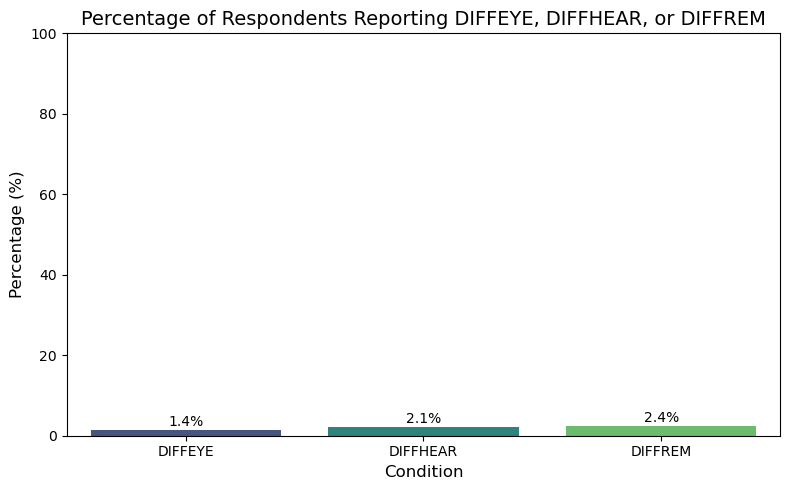

```python
conditions = ['DIFFEYE', 'DIFFHEAR', 'DIFFREM']
percentages = {condition: (ipums[condition] == 2).mean() * 100 for condition in conditions}

# Create a DataFrame for visualization
percent_df = pd.DataFrame({
    'Condition': percentages.keys(),
    'Percentage': percentages.values()
})

# Plot the data
plt.figure(figsize=(8, 5))
barplot = sns.barplot(data=percent_df, x='Condition', y='Percentage', palette='viridis')

# Annotate bars with percentage values
for index, row in percent_df.iterrows():
    barplot.text(index, row['Percentage'] + 1, f"{row['Percentage']:.1f}%",
                 color='black', ha='center', fontsize=10)

# Customize the plot
plt.title('Percentage of Respondents Reporting DIFFEYE, DIFFHEAR, or DIFFREM', fontsize=14)
plt.xlabel('Condition', fontsize=12)
plt.ylabel('Percentage (%)', fontsize=12)
plt.ylim(0, 100)
plt.xticks(fontsize=10)
plt.yticks(fontsize=10)

# Show the plot
plt.tight_layout()
plt.show()
```

### Overlap of Respondents Reporting DIFFEYE, DIFFHEAR, and DIFFREM

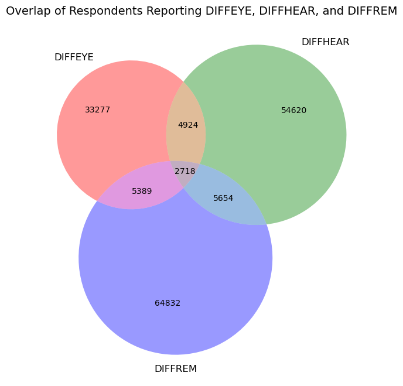

```python
# Create subsets for the Venn Diagram
eye_yes = set(ipums[ipums['DIFFEYE'] == 2].index)
hear_yes = set(ipums[ipums['DIFFHEAR'] == 2].index)
rem_yes = set(ipums[ipums['DIFFREM'] == 2].index)

# Plot the Venn Diagram
plt.figure(figsize=(8, 8))
venn = venn3([eye_yes, hear_yes, rem_yes],
             ('DIFFEYE', 'DIFFHEAR', 'DIFFREM'))

# Customize the diagram
plt.title('Overlap of Respondents Reporting DIFFEYE, DIFFHEAR, and DIFFREM', fontsize=14)
plt.show()
```